# Estudios de Informática, Multimedia y Telecomunicaciones

## 2.2 Creación del modelo, calidad del modelo y extracción de reglas

Se crea el árbol de decisión usando los datos de entrenamiento:

```r
model <- C50::C5.0(trainX, trainy,rules=TRUE )
summary(model)
```

```
##
## Call:
## C5.0.default(x = trainX, y = trainy, rules = TRUE)
##
##
## C5.0 [Release 2.07 GPL Edition]      Fri May 15 19:58:55 2020
## -------------------------------
##
## Class specified by attribute `outcome'
##
## Read 1467 cases (4 attributes) from undefined.data
##
## Rules:
##
## Rule 1: (1169/255, lift 1.2)
##  SEX = Hombre
##  ->  class Muere  [0.781]
##
## Rule 2: (20, lift 2.9)
##  CLASS in {1a, 2a}
##  AGE = Menor
##  ->  class Sobrevive  [0.955]
##
## Rule 3: (298/75, lift 2.3)
##  SEX = Mujer
##  ->  class Sobrevive  [0.747]
##
## Default class: Muere
##
##
## Evaluation on training data (1467 cases):
##
##          Rules
##    ----------------
##      No      Errors
##
##       3  317(21.6%)   <<
##
##
##     (a)   (b)    <-classified as
##    ----  ----
##     914    75    (a): class Muere
##     242   236    (b): class Sobrevive
##
##
##  Attribute usage:
##
##  100.00% SEX
##    1.36% CLASS
##    1.36% AGE
##
##
## Time: 0.0 secs
```

Por tanto podemos concluir que el conocimiento extraído y cruzado con el análisis visual se resume en “las mujeres y los niños primero a excepción de que fueras de 3ª clase”.

A continuación mostramos el árbol obtenido.

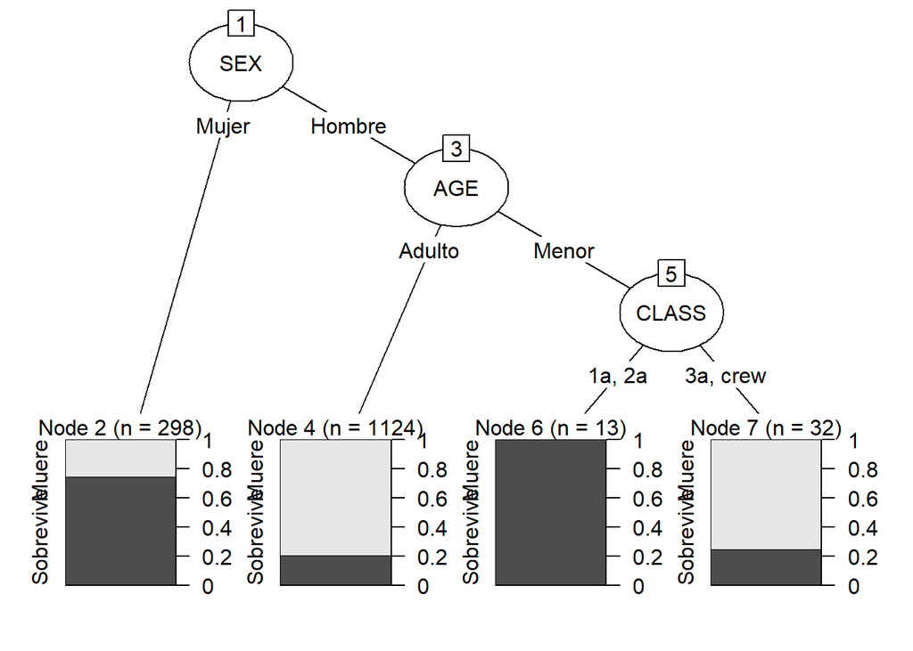

```r
model <- C50::C5.0(trainX, trainy)
plot(model)
```

## 2.3 Validación del modelo con los datos reservados

Una vez tenemos el modelo, podemos comprobar su calidad prediciendo la clase para los datos de prueba que nos hemos reservado al principio.

```r
predicted_model <- predict( model, testX, type="class" )
print(sprintf("La precisión del árbol es: %.4f %%",100*sum(predicted_model == testy) / length(predicted_model)))
```

```
## [1] "La precisión del árbol es: 78.2016 %"
```

Cuando hay pocas clases, la calidad de la predicción se puede analizar mediante una matriz de confusión que identifica los tipos de errores cometidos.

```r
mat_conf<-table(testy,Predicted=predicted_model)
mat_conf
```

```
##            Predicted
## testy       Muere Sobrevive
##   Muere       450        51
##   Sobrevive   109       124
```

Otra manera de calcular el porcentaje de registros correctamente clasificados usando la matriz de confusión:

```r
porcentaje_correct<-100 * sum(diag(mat_conf)) / sum(mat_conf)
print(sprintf("El %% de registros correctamente clasificados es: %.4f %%",porcentaje_correct))
```

```
## [1] "El % de registros correctamente clasificados es: 78.2016 %"
```

Además, tenemos a nuestra disposición el paquete gmodels para obtener información más completa:

```r
if(!require(gmodels)){
    install.packages('gmodels', repos='http://cran.us.r-project.org')
    library(gmodels)
}
CrossTable(testy, predicted_model,prop.chisq  = FALSE, prop.c = FALSE, prop.r =FALSE,dnn = c('Reality', 'Prediction'))
```

```
##
##
##    Cell Contents
## |-------------------------|
## |                       N |
## |         N / Table Total |
## |-------------------------|
##
##
## Total Observations in Table:  734
##
##
##              | Prediction
##      Reality |     Muere | Sobrevive | Row Total |
## -------------|-----------|-----------|-----------|
##        Muere |       450 |        51 |       501 |
##              |     0.613 |     0.069 |           |
## -------------|-----------|-----------|-----------|
##    Sobrevive |       109 |       124 |       233 |
##              |     0.149 |     0.169 |           |
## -------------|-----------|-----------|-----------|
## Column Total |       559 |       175 |       734 |
## -------------|-----------|-----------|-----------|
##
##
```

# 3 Ejercicios

## 3.1 Ejercicio 1:

Partiendo del ejemplo mostrado, repetid el ejercicio con otro conjunto de datos. Pueden ser datos reales de vuestro ámbito laboral o de algún repositorio de datos de Internet. Mirad por ejemplo: http://www.ics.uci.edu/~mlearn/MLSummary.html i http://www.kaggle.com.

Es muy importante seleccionar correctamente el conjunto de datos y explicar de forma correcta la base de datos y la razón de su elección.

Podéis añadir o variar los puntos si lo consideráis necesario (por ejemplo, crear el modelo con todos los datos y validación cruzada, probar el boosting o variar el prunning …) Recordad también que el ciclo de vida de los proyectos de minería contempla retroceder para volver a generar el modelo con datos modificados o parámetros del algoritmo variados si el resultado no es lo suficientemente bueno.

### 3.1.1 Respuesta 1:

#### 3.1.1.1 Revisión de los datos, extracción visual de información y preparación de los datos

Carga de los datos:

```r
df<-read.csv("./zoo.csv",header=T,sep=",")
attach(data)
```

```r
dim(df)
```

```
## [1] 101  18
```

```r
str(df)
```

```
## 'data.frame':    101 obs. of  18 variables:
##  $ animal_name: Factor w/ 100 levels "aardvark","antelope",..: 1 2 3 4 5 6 7 8 9 10 ...
##  $ hair       : int  1 1 0 1 1 1 1 0 0 1 ...
##  $ feathers   : int  0 0 0 0 0 0 0 0 0 0 ...
##  $ eggs       : int  0 0 1 0 0 0 0 1 1 0 ...
##  $ milk       : int  1 1 0 1 1 1 1 0 0 1 ...
##  $ airborne   : int  0 0 0 0 0 0 0 0 0 0 ...
##  $ aquatic    : int  0 0 1 0 0 0 0 1 1 0 ...
##  $ predator   : int  1 0 1 1 1 0 0 0 1 0 ...
##  $ toothed    : int  1 1 1 1 1 1 1 1 1 1 ...
##  $ backbone   : int  1 1 1 1 1 1 1 1 1 1 ...
##  $ breathes   : int  1 1 0 1 1 1 1 0 0 1 ...
##  $ venomous   : int  0 0 0 0 0 0 0 0 0 0 ...
##  $ fins       : int  0 0 1 0 0 0 0 1 1 0 ...
##  $ legs       : int  4 4 0 4 4 4 4 0 0 4 ...
##  $ tail       : int  0 1 1 0 1 1 1 1 1 0 ...
##  $ domestic   : int  0 0 0 0 0 0 1 1 0 1 ...
##  $ catsize    : int  1 1 0 1 1 1 1 0 0 0 ...
##  $ class_type : int  1 1 4 1 1 1 1 4 4 1 ...
```

```r
summary(df)
```

```
##    animal_name      hair           feathers          eggs
##  frog    : 2   Min.   :0.0000   Min.   :0.000   Min.   :0.0000
##  aardvark: 1   1st Qu.:0.0000   1st Qu.:0.000   1st Qu.:0.0000
##  antelope: 1   Median :0.0000   Median :0.000   Median :1.0000
##  bass    : 1   Mean   :0.4257   Mean   :0.198   Mean   :0.5842
##  bear    : 1   3rd Qu.:1.0000   3rd Qu.:0.000   3rd Qu.:1.0000
##  boar    : 1   Max.   :1.0000   Max.   :1.000   Max.   :1.0000
##  (Other) :94
##       milk           airborne         aquatic          predator
##  Min.   :0.0000   Min.   :0.0000   Min.   :0.0000   Min.   :0.0000
##  1st Qu.:0.0000   1st Qu.:0.0000   1st Qu.:0.0000   1st Qu.:0.0000
##  Median :0.0000   Median :0.0000   Median :0.0000   Median :1.0000
##  Mean   :0.4059   Mean   :0.2376   Mean   :0.3564   Mean   :0.5545
##  3rd Qu.:1.0000   3rd Qu.:0.0000   3rd Qu.:1.0000   3rd Qu.:1.0000
##  Max.   :1.0000   Max.   :1.0000   Max.   :1.0000   Max.   :1.0000
##
##     toothed         backbone         breathes         venomous
##  Min.   :0.000   Min.   :0.0000   Min.   :0.0000   Min.   :0.00000
##  1st Qu.:0.000   1st Qu.:1.0000   1st Qu.:1.0000   1st Qu.:0.00000
##  Median :1.000   Median :1.0000   Median :1.0000   Median :0.00000
##  Mean   :0.604   Mean   :0.8218   Mean   :0.7921   Mean   :0.07921
##  3rd Qu.:1.000   3rd Qu.:1.0000   3rd Qu.:1.0000   3rd Qu.:0.00000
##  Max.   :1.000   Max.   :1.0000   Max.   :1.0000   Max.   :1.00000
##
##       fins             legs            tail           domestic
##  Min.   :0.0000   Min.   :0.000   Min.   :0.0000   Min.   :0.0000
##  1st Qu.:0.0000   1st Qu.:2.000   1st Qu.:0.0000   1st Qu.:0.0000
##  Median :0.0000   Median :4.000   Median :1.0000   Median :0.0000
##  Mean   :0.1683   Mean   :2.842   Mean   :0.7426   Mean   :0.1287
##  3rd Qu.:0.0000   3rd Qu.:4.000   3rd Qu.:1.0000   3rd Qu.:0.0000
##  Max.   :1.0000   Max.   :8.000   Max.   :1.0000   Max.   :1.0000
##
##     catsize         class_type
##  Min.   :0.0000   Min.   :1.000
##  1st Qu.:0.0000   1st Qu.:1.000
##  Median :0.0000   Median :2.000
##  Mean   :0.4356   Mean   :2.832
##  3rd Qu.:1.0000   3rd Qu.:4.000
##  Max.   :1.0000   Max.   :7.000
##
```

Removemos la primera columna, pues los nombres de los animales alteraría nuestro resultado final, sería muy bueno pero no tendría mérito alguno.

```r
df<-df[,2:18]
head(df)
```

```
##   hair feathers eggs milk airborne aquatic predator toothed backbone breathes
## 1    1        0    0    1        0       0        1       1        1        1
## 2    1        0    0    1        0       0        0       1        1        1
## 3    0        0    1    0        0       1        1       1        1        0
## 4    1        0    0    1        0       0        1       1        1        1
## 5    1        0    0    1        0       0        1       1        1        1
## 6    1        0    0    1        0       0        0       1        1        1
##   venomous fins legs tail domestic catsize class_type
## 1        0    0    4    0        0       1          1
## 2        0    0    4    1        0       1          1
## 3        0    1    0    1        0       0          4
## 4        0    0    4    0        0       1          1
## 5        0    0    4    1        0       1          1
## 6        0    0    4    1        0       1          1
```

Comprobamos valores nulos.No hay.

```r
colSums(is.na(df))
```

```
##       hair   feathers       eggs       milk   airborne    aquatic   predator
##          0          0          0          0          0          0          0
##    toothed   backbone   breathes   venomous       fins       legs       tail
##          0          0          0          0          0          0          0
##   domestic    catsize class_type
##          0          0          0
```

```r
colSums(df==" ")
```

```
##       hair   feathers       eggs       milk   airborne    aquatic   predator
##          0          0          0          0          0          0          0
##    toothed   backbone   breathes   venomous       fins       legs       tail
##          0          0          0          0          0          0          0
##   domestic    catsize class_type
##          0          0          0
```

En las anteriores salidas, se puede ver que todas las varibale sparecen categóricas. Hacemos una comprobación de esto.

```r
lapply(df, table)
```

```
## $hair
##
##  0  1
## 58 43
##
## $feathers
##
##  0  1
## 81 20
##
## $eggs
##
##  0  1
## 42 59
##
## $milk
##
##  0  1
## 60 41
##
## $airborne
##
##  0  1
## 77 24
##
## $aquatic
##
##  0  1
## 65 36
##
## $predator
##
##  0  1
## 45 56
##
## $toothed
##
##  0  1
## 40 61
##
```

[output cut: 29 more lines]

```
##
## $domestic
##
##  0  1
## 88 13
##
## $catsize
##
##  0  1
## 57 44
##
## $class_type
##
##  1  2  3  4  5  6  7
## 41 20  5 13  4  8 10
```

Vemos que salvo la variable “legs”, todas las clases solo tienen un rango de 2. Esto nos revela que probablemente sea muy complicado la discretización. Aunque por otra parte, si alguna variable que no sea legs se puede discretizar, eso implicará que se puede eliminar, quitando dimensionalidad y complejidad a nuestro problema.

Hacemos un análisis de todas las variables en relación con la variable “class_type” para ver si podemos obtener algo de provecho.

Utilizaremos las tablas de contingencia como herramienta para visualizar los datos, establecemos la variable “class_type” como eje x para que se vea mejor.

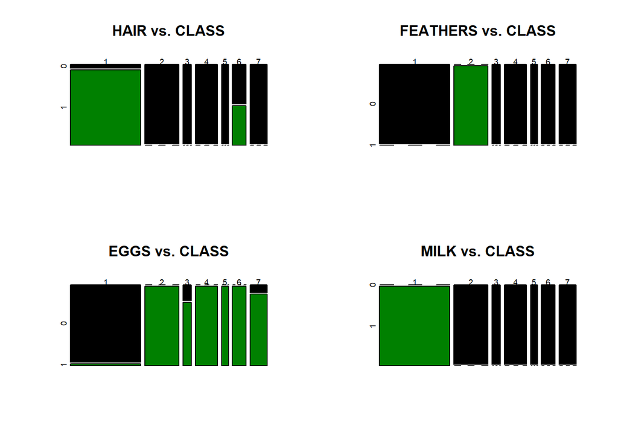

```r
tabla_1 <- table(df$class_type,df$hair)
tabla_2 <- table(df$class_type,df$feathers)
tabla_3 <- table(df$class_type,df$eggs)
tabla_4 <- table(df$class_type,df$milk)
tabla_5 <- table(df$class_type,df$airborne)
tabla_6 <- table(df$class_type,df$aquatic)
tabla_7 <- table(df$class_type,df$predator)
tabla_8 <- table(df$class_type,df$toothed)
tabla_9 <- table(df$class_type,df$backbone)
tabla_10 <- table(df$class_type,df$breathes)
tabla_11 <- table(df$class_type,df$venomous)
tabla_12 <- table(df$class_type,df$fins)
tabla_13 <- table(df$class_type,df$legs)
tabla_14 <- table(df$class_type,df$tail)
tabla_15 <- table(df$class_type,df$domestic)
tabla_16 <- table(df$class_type,df$catsize)

par(mfrow=c(2,2))
plot(tabla_1, col = c("black","#008000"), main = "HAIR vs. CLASS")
plot(tabla_2, col = c("black","#008000"), main = "FEATHERS vs. CLASS")
plot(tabla_3, col = c("black","#008000"), main = "EGGS vs. CLASS")
plot(tabla_4, col = c("black","#008000"), main = "MILK vs. CLASS")
```

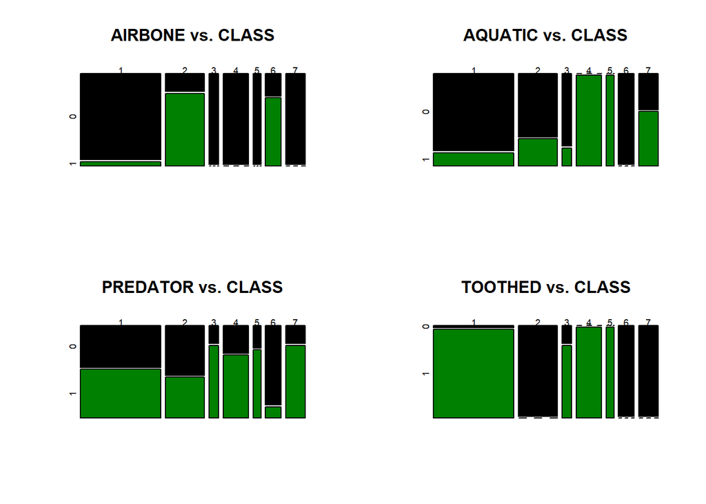

```r
plot(tabla_5, col = c("black","#008000"), main = "AIRBONE vs. CLASS")
plot(tabla_6, col = c("black","#008000"), main = "AQUATIC vs. CLASS")
plot(tabla_7, col = c("black","#008000"), main = "PREDATOR vs. CLASS")
plot(tabla_8, col = c("black","#008000"), main = "TOOTHED vs. CLASS")
```

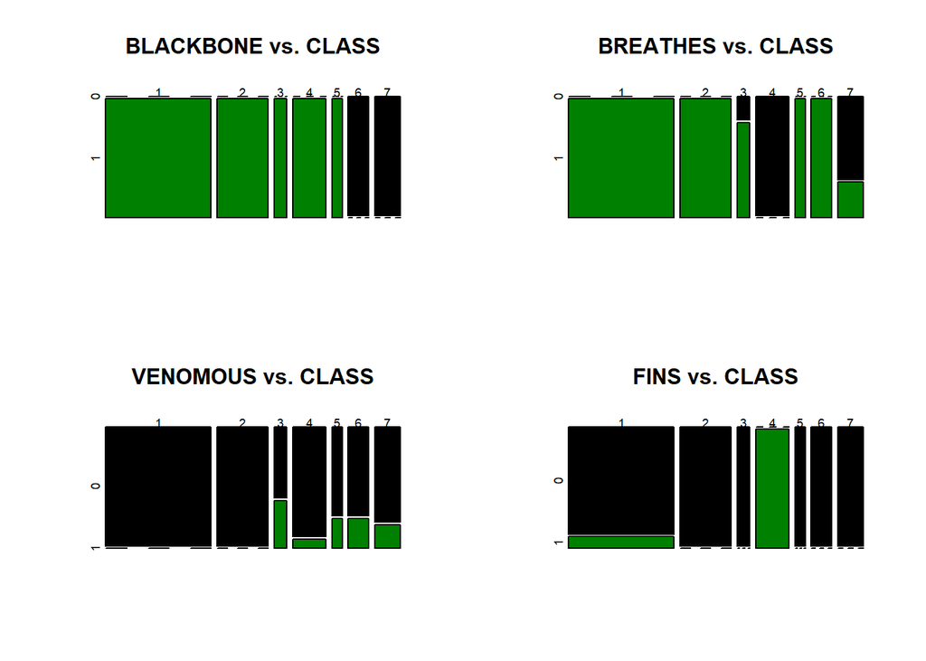

```r
plot(tabla_9, col = c("black","#008000"), main = "BLACKBONE vs. CLASS")
plot(tabla_10, col = c("black","#008000"), main = "BREATHES vs. CLASS")
plot(tabla_11, col = c("black","#008000"), main = "VENOMOUS vs. CLASS")
plot(tabla_12, col = c("black","#008000"), main = "FINS vs. CLASS")
```

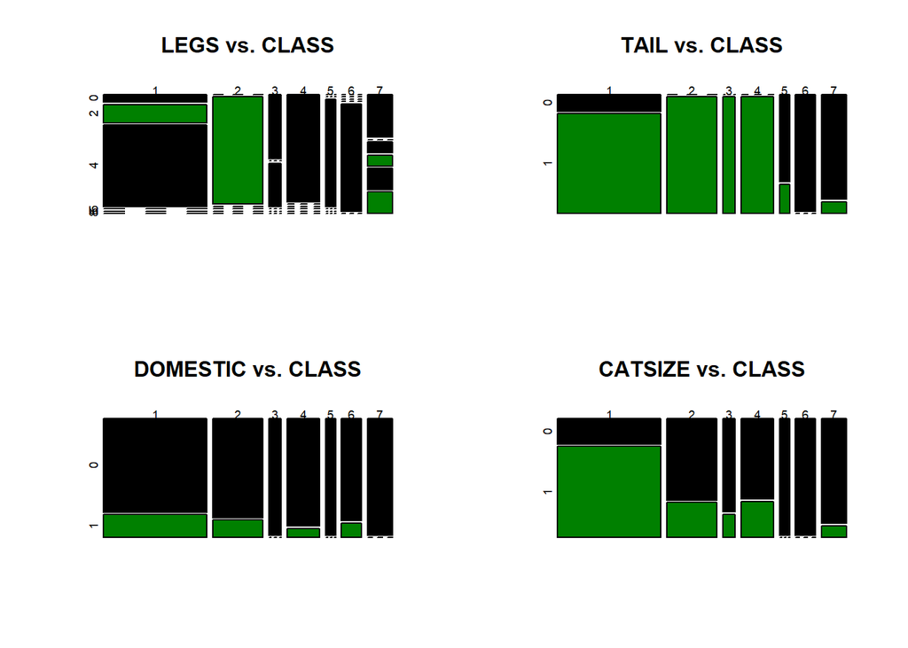

```r
plot(tabla_13, col = c("black","#008000"), main = "LEGS vs. CLASS")
plot(tabla_14, col = c("black","#008000"), main = "TAIL vs. CLASS")
plot(tabla_15, col = c("black","#008000"), main = "DOMESTIC vs. CLASS")
plot(tabla_16, col = c("black","#008000"), main = "CATSIZE vs. CLASS")
```

```r
tabla_13
```

```
##
##      0  2  4  5  6  8
##   1  3  7 31  0  0  0
##   2  0 20  0  0  0  0
##   3  3  0  2  0  0  0
##   4 13  0  0  0  0  0
##   5  0  0  4  0  0  0
##   6  0  0  0  0  8  0
##   7  4  0  1  1  2  2
```

Nos interesará “desordenarlos”. Guardaremos los datos con el nuevo nombre como “df_random”.

```r
set.seed(1)
df_random <- df[sample(nrow(df)),]
```

```r
set.seed(666)
y <- as.factor(df_random[,17])
X <- df_random[,1:16]
```

```r
indexes = sample(1:nrow(df), size=floor((2/3)*nrow(df)))
x_train<-X[indexes,]
y_train<-y[indexes]
x_test<-X[-indexes,]
y_test<-y[-indexes]
length(y_train)
```

```
## [1] 67
```

```r
length(y_test)
```

```
## [1] 34
```

Evaluaremos el árbol en 34 casos. Lo entrenaremos con 67.

#### 3.1.1.2 Creación del modelo, calidad del modelo y extracción de reglas

```r
model <- C50::C5.0(x_train, y_train,rules=TRUE )
summary(model)
```

```
##
## Call:
## C5.0.default(x = x_train, y = y_train, rules = TRUE)
##
##
## C5.0 [Release 2.07 GPL Edition]      Fri May 15 19:58:56 2020
## -------------------------------
##
## Class specified by attribute `outcome'
##
## Read 67 cases (17 attributes) from undefined.data
##
## Rules:
##
## Rule 1: (23, lift 2.8)
##  milk > 0
##  ->  class 1  [0.960]
##
## Rule 2: (12, lift 5.2)
##  feathers > 0
##  ->  class 2  [0.929]
##
## Rule 3: (4, lift 14.0)
##  feathers <= 0
##  milk <= 0
##  fins <= 0
##  tail > 0
##  ->  class 3  [0.833]
##
## Rule 4: (11, lift 5.6)
##  milk <= 0
##  fins > 0
##  ->  class 4  [0.923]
##
## Rule 5: (2, lift 25.1)
##  milk <= 0
##  toothed > 0
##  tail <= 0
##  ->  class 5  [0.750]
##
```

[output cut: 30 more lines]

```
##                                     6          (f): class 6
##                                           9    (g): class 7
##
##
##  Attribute usage:
##
##   59.70% milk
##   31.34% tail
##   23.88% feathers
##   22.39% airborne
##   22.39% fins
##   16.42% toothed
##
##
## Time: 0.0 secs
```

Vemos que de la muestra de entrenamiento ha sido todo un éxito, con un 0% de fallo. esto es debido a que, a diferencia de en el ejemplo del titanic, aquí hay 7 clases en lugar de dos. Al tratarse de un tema como los animales, es normal que el entrenamiento haya ido tan bien, pues pocos son los animales que no cuadran en muchas características con los de sus demás especies, como podría ser el ornitorrinco, un mamífero que pone huevos.

A partir del árbol de decisión modelado podemos extraer las siguientes 7 reglas de decisión:

- Regla 1. Si el animal bebe leche, pertenece a las clase 1 con una confianza de 0.96, probablemente la clase 1 sea la de los mamíferos.
- Regla 2. Si tiene plumas, pertenece a la segunda clase, con una confianza de 0.929.
- Regla 3. si no tiene plumas, ni bebe leche, ni aletas y tiene cola, pertenece a la clase 3 con una confianza del 0.833.
- Regla 4. si no bebe leche y tiene aletas, es de la clase 4 con una confianza de 0.923.
- Regla 5. Si tiene dientes, pero no bebe leche ni tiene cola, pertenece a la clase 5 con confianza de 0.75
- Regla 6. Si es volador y no tiene cola, entonces clase 6, con una confianza de 0.875.
- Regla 7. Si no vuela, no tiene cola ni dientes, pertenece a la clase 7. confianza igual a 0.909.

[figure not shown]

```r
model <- C50::C5.0(x_train, y_train)
plot(model)
```

#### 3.1.1.3 Validación del modelo con los datos reservados

Procedemos ahora a evaluar la calidad del modelo con los datos de prueba.

```r
predicted_model <- predict( model, x_test, type="class" )
print(sprintf("La precisión del árbol es: %.4f %%",100*sum(predicted_model == y_test) / length(predicted_model)))
```

```
## [1] "La precisión del árbol es: 88.2353 %"
```

Este incremento en el error en comparación con el entrenamiento se debe a que hay ciertos casos que no se han recogido en el entrenamiento a pesar de haber barajado los datos.

```r
mat_conf<-table(y_test,Predicted=predicted_model)
mat_conf
```

```
##       Predicted
## y_test  1  2  3  4  5  6  7
##      1 18  0  0  0  0  0  0
##      2  0  8  0  0  0  0  0
##      3  0  0  1  0  0  0  0
##      4  0  0  0  2  0  0  0
##      5  0  0  1  0  1  0  0
##      6  0  0  0  0  0  0  2
##      7  0  0  1  0  0  0  0
```

Probamos ahora con testeando con el 100% de los datos.

```r
y <- as.factor(df_random[,17])
X <- df_random[,1:16]

model2 <- C50::C5.0(X, y,rules=TRUE)
predicted_model <- predict( model2, X, type="class" )
print(sprintf("La precisión del árbol es: %.4f %%",100*sum(predicted_model == y) / length(predicted_model)))
```

```
## [1] "La precisión del árbol es: 99.0099 %"
```

Esto se debe, a que al haber entrenado con el dataset entero, el modelo ha podido definir reglas y matizarlas para los casos atípicos, los cuales nos daban fallo en la anterior prueba. Solo falla en un caso.

## 3.2 Otro modelo

```r
cols<-colnames(df)
df2<- lapply(df[cols], factor)
```

```r
library(RWeka)
library(ipred)
#Bagging CART

fit <- bagging(class_type~., data=data.frame(df2))
predictions <- predict(fit, df2[1:17])
```

```r
table(predictions, df2$class_type)
```

```
##
## predictions  1  2  3  4  5  6  7
##           1 41  0  0  0  0  0  0
##           2  0 20  0  0  0  0  0
##           3  0  0  5  0  0  0  0
##           4  0  0  0 13  0  0  0
##           5  0  0  0  0  4  0  0
##           6  0  0  0  0  0  8  0
##           7  0  0  0  0  0  0 10
```

De nuevo la precisión es muy alta, esta vez incluso superior al modelo anterior.

Esto es debido a que ha diferencia del C50, en el CART, el procedimiento de construcción del árbol pasa por considerar en cada momento el hecho de encontrar el atributo que actúa mejor como separador, lo que nos ha beneficiado en el único caso de error que teníamos.

### 3.2.1 Conclusiones

Los árboles de decisión son un método de clasificación muy potente que además nos proporciona reglas de clasificación. Representan una venzaja en comparación con el método generador de reglas de asociación de la anterior práctica.

Resulta destacable que a penas haya diferencias de rendimiento entre los métodos presentados en esta práctica, esto puede justificarse debido a la naturaleza de nuestro set de datos. El cual, al ser una dataframe con información de animales, ignora en gran parte el factor de aleatoriedad que se podrían presentar en otros sets como el del titanic. No obstante, este nos permite no solo comprobar el funcionamiento de ambos algortimos si no también su eficacia.

# 4 Bibliografía

- Dataset: https://archive.ics.uci.edu/ml/datasets/Zoo
- https://stackoverflow.com/questions/6286313/remove-an-entire-column-from-a-data-frame-in-r
- https://stackoverflow.com/questions/13383840/select-multiple-columns-in-data-table-by-their-numeric-indices/13383995
- https://stackoverflow.com/questions/13312477/count-unique-categorical-values-in-r
- https://www.kaggle.com/c/can-we-predict-voting-outcomes/discussion/21518
- https://stackoverflow.com/questions/31029592/c5-0-models-require-a-factor-outcome
- https://www.statmethods.net/advgraphs/layout.html
- rulequest.com/see5-unix.html
- https://topepo.github.io/C5.0/reference/C5.0.html
- https://topepo.github.io/C5.0/reference/plot.C5.0.html
- https://stat.ethz.ch/R-manual/R-devel/library/base/html/colnames.html
- https://stackoverflow.com/questions/34865798/r-weka-j48-decision-tree-cannot-handle-numeric-class
- https://rdrr.io/cran/RKEEL/man/C45-C.html
- https://stackoverflow.com/questions/4227223/convert-a-list-to-a-data-frame

# 5 Rúbrica

- 15% Se explica de forma clara la base de datos seleccionada y la razón de su elección.
- 10% Hay un estudio sobre los datos de los que se parte y los datos son preparados correctamente.
- 20% Se aplica un árbol de decisión de forma correcta y se obtiene una estimación del error.
- 5% Se muestra de forma gráfica el árbol obtenido.
- 10% Se explican las reglas que se obtienen.
- 10% Se usa el modelo para predecir con muestras no usadas en el entrenamiento y se obtiene una estimación del error.
- 15% Se prueba otro modelo de árbol o variantes diferentes del C50 obteniendo mejores resultados.
- 5% Se presenta el código y es fácilmente reproducible.
- 10% Se presenta unas conclusiones donde se expone el conocimiento adquirido tras el trabajo realizado.